# Lecture #1: Calculus I Review

MATH 146 – Calculus II

Torin Quinlivan

tquinlivan@knox.edu

Knox College

January 5, 2026

## Limits

Given a function $f$, a fixed input $x=a$, and a real number $L$, we say that $f$ has limit $L$ as $x$ approaches $a$, and write

$$\lim_{x \to a} f(x) = L,$$

provided that we can make $f(x)$ as close to $L$ as we like by taking $x$ sufficiently close (but not equal) to $a$.

If we cannot make $f(x)$ as close to a single value as we would like as $x$ approaches $a$, then we say that $f$ does not have a limit as $x$ approaches $a$.

## Limits Example

## Left-Hand Limits

We say that $f$ has limit $L_1$ as $x$ approached $a$ from the left and write

$$\lim_{x \to a^-} f(x) = L_1,$$

provided that we can make the value of $f(x)$ as close to $L_1$ as we like by taking $x$ sufficiently close to $a$, while always having $x < a$.

We call $L_1$ the left-hand limit of $f$ as $x$ approaches $a$.

## Right-Hand Limits

We say that $f$ has limit $L_2$ as $x$ approached $a$ from the right and write

$$\lim_{x \to a^+} f(x) = L_2,$$

provided that we can make the value of $f(x)$ as close to $L_2$ as we like by taking $x$ sufficiently close to $a$, while always having $x > a$.

We call $L_1$ the right-hand limit of $f$ as $x$ approaches $a$.

## Left-Hand and Right-Hand Limits

A function $f$ has limit $L$ as $x \to a$ if and only if

$$\lim_{x \to a^-} f(x) = L = \lim_{x \to a^+} f(x).$$

## Limits Example

## Continuity

What does it mean for a function to be continuous? A function $f$ is continuous at $x=a$ provided that:

- $f$ has a limit as $x \to a$,
- $f$ is defined at $x=a$, and
- $\lim\limits_{x \to a} f(x) = f(a)$.

## Limits Example

## The Limit Does Not Exist!

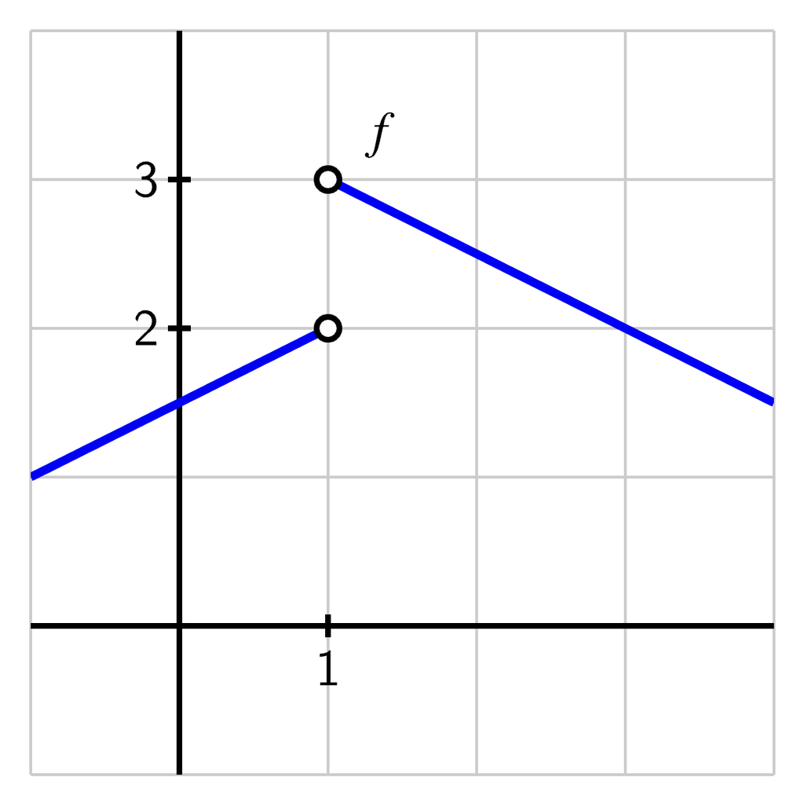

## The Derivative Function

This leads us to the following definition:

Let $f$ be a function and $x$ a value in the function’s domain.

We define the derivative of $f$, a new function called $f'$, by the formula

$$f'(x) = \lim\limits_{h \to 0} \frac{f(x + h) - f(x)}{h},$$

provided this limit exists.

$f'(x)$ is sometimes written as $\dfrac{d}{dx} f(x)$.

## Application of the Derivative

We say that $f$ is increasing on $(a, b)$ provided that the function is always rising as we move from left to right. That is, for any $x$ and $y$ in $(a,b)$, if $x < y$, then $f(x) < f(y)$.

We say that $f$ is decreasing on $(a, b)$ provided that the function is always falling as we move from left to right. That is, for any $x$ and $y$ in $(a,b)$, if $x < y$, then $f(x) > f(y)$.

## Application of the Derivative

Let $f$ be a function that is differentiable on an interval $(a, b)$. If $f'(x) > 0$ for every $x$ such that $a < x < b$, then $f$ is increasing on $(a, b)$.

Let $f$ be a function that is differentiable on an interval $(a, b)$. If $f'(x) < 0$ for every $x$ such that $a < x < b$, then $f$ is decreasing on $(a, b)$.

## Differentiability

We say that a function $f$ is differentiable at $x = a$ if it has a derivative at $x = a$.

If $f$ is differentiable at $x = a$, the $f$ is continuous at $x = a$. Equivalently, if $f$ fails to be continuous at $x = a$, the $f$ will not be differentiable at $x = a$.

A function can be continuous at a point, but not be differentiable there. In particular, a function $f$ is not differentiable at $x = a$ if the graph has a sharp corner (or *cusp*) at the point $(a, f(a))$.

If $f$ is differentiable at $x = a$, the $f$ is *locally linear* at $x = a$. That is, when a function is differentiable, it looks linear when viewed up close because it resembles its tangent line there.

## Example: Continuity and Differentiability

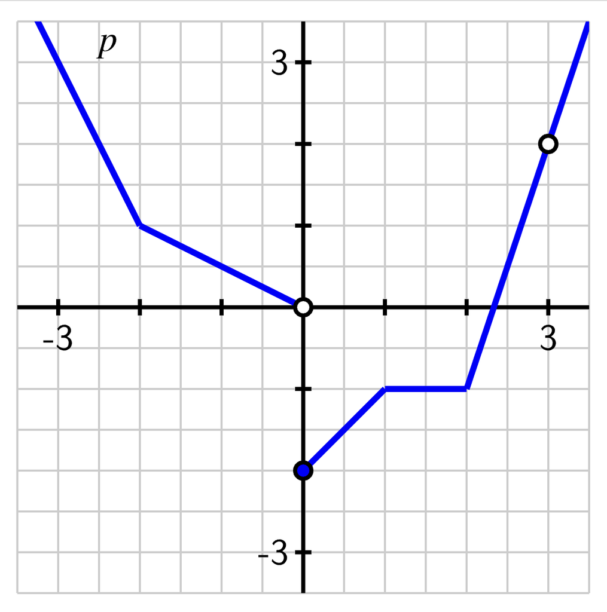

## The Constant Multiple Rule

For any real number $k$, if $f(x)$ is a differentiable function with derivative $f'(x)$, then
$$\frac{d}{dx} \left[ k f(x) \right] = k f'(x).$$

## The Sum Rule

If $f(x)$ and $g(x)$ are differentiable functions with derivatives $f'(x)$ and $g'(x)$ respectively, then
$$\frac{d}{dx} [f(x) + g(x)] = f'(x) + g'(x).$$

## The Power Rule

For any nonzero real number $n$, if $f(x) = x^n$, then
$$f'(x) = nx^{n-1}.$$

## The Product Rule

If $f$ and $g$ are differentiable functions, then their product $P(x) = (f \cdot g)(x) = f(x) \cdot g(x)$ is also a differentiable function, and

$$P'(x) = f(x) g'(x) + g(x)f'(x).$$

## The Quotient Rule

If $f$ and $g$ are differentiable functions, then their quotient $Q(x) = \frac{f(x)}{g(x)}$ is also a differentiable function for all $x$ where $g(x) \ne 0$, where

$$Q'(x) = \frac{g(x)f'(x) - f(x)g'(x)}{\left(g(x)\right)^2}.$$

## The Chain Rule

If $f$ and $g$ are differentiable functions, then:

$$\frac{d}{dx} (f \circ g)(x) = \frac{d}{dx} f(g(x)) = f'(g(x)) \cdot g'(x).$$

## Derivatives of Trigonometric Functions

- $\dfrac{d}{dx} \sin(x) = \cos(x)$.
- $\dfrac{d}{dx} \cos(x) = -\sin(x)$.
- $\dfrac{d}{dx} \tan(x) = \sec^2(x)$.
- $\dfrac{d}{dx} \sec(x) = \sec(x) \tan(x)$.
- $\dfrac{d}{dx} \csc(x) = -\csc(x) \cot(x)$.
- $\dfrac{d}{dx} \cot(x) = -\csc^2(x)$.

## Derivatives of Inverse Trigonometric Functions

- $\dfrac{d}{dx} \sin^{-1}(x) = \dfrac{1}{\sqrt{1 - x^2}}, \, \text{for } \lvert x \rvert < 1$.
- $\dfrac{d}{dx} \cos^{-1}(x) = -\dfrac{1}{\sqrt{1 - x^2}}, \, \text{for } \lvert x \rvert < 1$.
- $\dfrac{d}{dx} \tan^{-1}(x) = \dfrac{1}{1+x^2}$.
- $\dfrac{d}{dx} \sec^{-1}(x) = \dfrac{1}{\lvert x \rvert \sqrt{x^2 - 1}}, \, \text{for } \lvert x \rvert > 1$.
- $\dfrac{d}{dx} \csc^{-1}(x) = -\dfrac{1}{\lvert x \rvert \sqrt{x^2 - 1}}, \, \text{for } \lvert x \rvert > 1$.
- $\dfrac{d}{dx} \cot^{-1}(x) = - \dfrac{1}{1+x^2}$.

## Derivatives of Exponential & Logarithmic Functions

- $\dfrac{d}{dx} e^x = e^x$.
- $\dfrac{d}{dx} a^x = a^x \ln\left(a\right)$.
- $\dfrac{d}{dx} \ln\left(x\right) = \dfrac{1}{x}, \, x > 0$.
- $\dfrac{d}{dx} \log_{a}\left(x\right) = \dfrac{1}{x \ln\left(a\right)}, \, x > 0$.

## Antiderivatives and Integral Notation

If $f(x)$ is a function, then an antiderivative of $f(x)$ is a function $F(x)$ such that $F'(x) = f(x)$.

If $f(x)$ is a function, then the most general antiderivative of $f(x)$ is denoted by:
$$\int f(x)\,dx.$$

**Example:**
$$\int 2x\,dx = x^2 + C.$$

## Rules for Antiderivatives

**Rules for Finding Antiderivatives:**

- (Inverse) Power Rule:

$$\int x^n\,dx = \frac{x^{n+1}}{n+1} + C,\textrm{for all $n \ne -1$}.$$

- Sum Rule:

$$\int \left( f(x) + g(x) \right)\,dx = \int f(x)\,dx + \int g(x)\,dx.$$

## Rules for Antiderivatives

**Rules for Finding Antiderivatives:**

- Constant Multiple Rule:

$$\int cf(x)\,dx = c \int f(x)\,dx.$$

## Differential Equations

A differential equation is an equation that relates an unknown function $y(x)$ and one or more of its derivatives.

A differential equation with an initial condition $y(x_0) = y_0$ is an initial value problem.